# Two Means - Independent Samples Example

# Problem Statement

Average income varies from one region of the country to another, and it often reflects both lifestyles and regional living expenses. Suppose a new graduate is considering a job in two locations, Cleveland, OH and Sacramento, CA, and he wants to see whether the average income in one of these cities is higher than the other. He would like to conduct a hypothesis test based on two randomly selected samples from the 2000 Census. (Tweaked a bit from Diez et al. 2015 [Chapter 5])

# Competing Hypotheses

## In words

- Null hypothesis: There is no association between income and location (Cleveland, OH and Sacramento, CA).
- Alternative hypothesis: There is an association between income and location (Cleveland, OH and Sacramento, CA).

## Another way in words

- Null hypothesis: The mean income is the **same** for both cities.
- Alternative hypothesis: The mean income is different for the two cities.

## In symbols (with annotations)

- $H_0: \mu_{sac} = \mu_{cle}$ or $H_0: \mu_{sac} - \mu_{cle} = 0$, where $\mu$ represents the average income.
- $H_A: \mu_{sac} - \mu_{cle} \ne 0$

## Set $\alpha$

It’s important to set the significance level before starting the testing using the data. Let’s set the significance level at 5% here.

# Exploring the sample data

```r
cle_sac <- read.delim("cleSac.txt") |>
  rename(metro_area = Metropolitan_area_Detailed,
         income = Total_personal_income) |>
  na.omit()
```

```r
inc_summ <- cle_sac |>
  group_by(metro_area) |>
  summarize(sample_size = n(),
    mean = mean(income),
    sd = sd(income),
    minimum = min(income),
    lower_quartile = quantile(income, 0.25),
    median = median(income),
    upper_quartile = quantile(income, 0.75),
    max = max(income))
kable(inc_summ)
```

| metro_area | sample_size | mean | sd | minimum | lower_quartile | median | upper_quartile | max |
| --- | --- | --- | --- | --- | --- | --- | --- | --- |
| Cleveland_ OH | 212 | 27467 | 27681 | 0 | 8475 | 21000 | 35275 | 152400 |
| Sacramento_ CA | 175 | 32428 | 35774 | 0 | 8050 | 20000 | 49350 | 206900 |

The boxplot below also shows the mean for each group highlighted by the red dots.

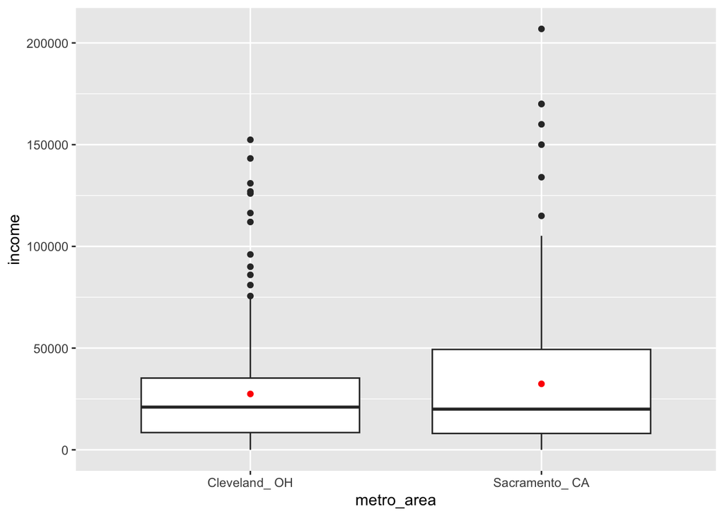

```r
cle_sac |> ggplot(aes(x = metro_area, y = income)) +
  geom_boxplot() +
  stat_summary(fun = "mean", geom = "point", color = "red")
```

## Guess about statistical significance

We are looking to see if a difference exists in the mean income of the two levels of the explanatory variable. Based solely on the boxplot, we have reason to believe that no difference exists. The distributions of income seem similar and the means fall in roughly the same place.

# Non-traditional methods

We’ll use the **`infer`** package to carry out the simulation-based workflow.

## Observed statistic

```r
d_hat <- cle_sac |>
  specify(income ~ metro_area) |>
  calculate(
    stat = "diff in means",
    order = c("Sacramento_ CA", "Cleveland_ OH")
  )
d_hat
```

```
## Response: income (numeric)
## Explanatory: metro_area (factor)
## # A tibble: 1 × 1
##    stat
##   <dbl>
## 1 4960.
```

## Randomization for Hypothesis Test

In order to look to see if the observed difference in mean income (Sacramento minus Cleveland) of 4960.47682 is statistically different than 0, we need to account for the sample sizes. We can use the idea of *randomization testing* (also known as *permutation testing*): under the null of no association, the `metro_area` labels are exchangeable, so `infer` shuffles them with `hypothesize(null = "independence")` and recomputes the difference in means 10,000 times.

```r
set.seed(2018)
null_distn_two_means <- cle_sac |>
  specify(income ~ metro_area) |>
  hypothesize(null = "independence") |>
  generate(reps = 10000) |>
  calculate(
    stat = "diff in means",
    order = c("Sacramento_ CA", "Cleveland_ OH")
  )
```

We can next use this distribution to observe our $p$-value. Recall this is a two-tailed test so we will be shading values at least as extreme as our observed difference in both directions.

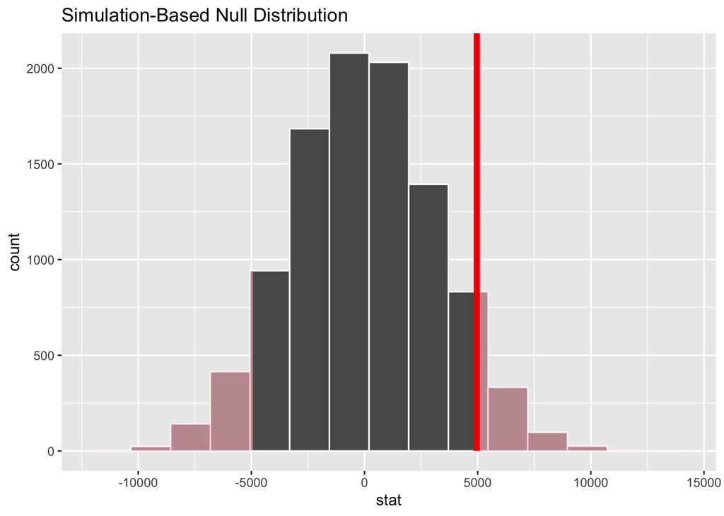

```r
null_distn_two_means |>
  visualize() +
  shade_p_value(obs_stat = d_hat, direction = "both")
```

### Calculate $p$-value

```r
pvalue <- null_distn_two_means |>
  get_p_value(obs_stat = d_hat, direction = "both")
pvalue
```

```
## # A tibble: 1 × 1
##   p_value
##     <dbl>
## 1   0.126
```

So our $p$-value is 0.1262 and we fail to reject the null hypothesis at the 5% level. You can also see this from the histogram above that we are not very far into the tail of the null distribution.

## Bootstrapping for Confidence Interval

```r
boot_distn_two_means <- cle_sac |>
  specify(income ~ metro_area) |>
  generate(reps = 10000, type = "bootstrap") |>
  calculate(
    stat = "diff in means",
    order = c("Sacramento_ CA", "Cleveland_ OH")
  )

ci <- boot_distn_two_means |>
  get_confidence_interval(level = 0.95)
ci
```

```
## # A tibble: 1 × 2
##   lower_ci upper_ci
##      <dbl>    <dbl>
## 1   -1359.   11500.
```

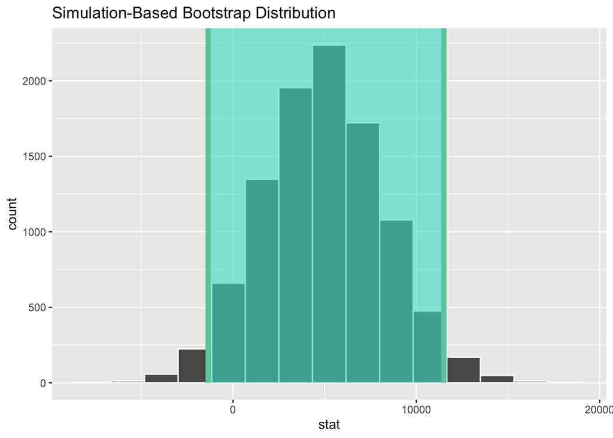

```r
boot_distn_two_means |>
  visualize() +
  shade_confidence_interval(endpoints = ci)
```

We see that 0 is contained in this confidence interval as a plausible value of $\mu_{sac} - \mu_{cle}$ (the unknown population parameter). This matches with our hypothesis test results of failing to reject the null hypothesis. Since zero is a plausible value of the population parameter, we do not have evidence that Sacramento incomes are different than Cleveland incomes.

**Interpretation**: We are 95% confident the true difference in mean yearly income (Sacramento minus Cleveland) is between -1359.49781 and 11499.69111 dollars.

# Traditional methods

## Check conditions

Remember that in order to use the short-cut (formula-based, theoretical) approach, we need to check that some conditions are met.

1. *Independent observations*: The observations are independent in both groups.

   This `metro_area` variable is met since the cases are randomly selected from each city.
2. *Approximately normal*: The distribution of the response for each group should be normal or the sample sizes should be at least 30.

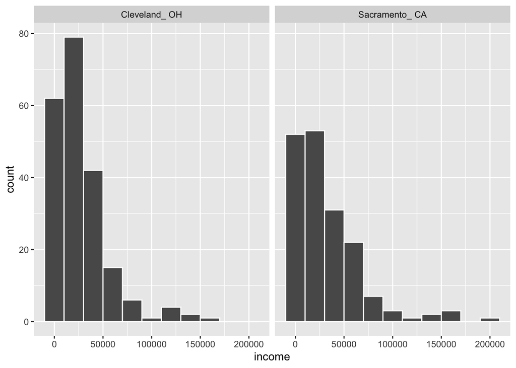

   ```r
   cle_sac |> ggplot(aes(x = income)) +
     geom_histogram(color = "white", binwidth = 20000) +
     facet_wrap(~ metro_area)
   ```

   We have some reason to doubt the normality assumption here since both the histograms show deviation from a normal model fitting the data well for each group. The sample sizes for each group are greater than 100 though so the assumptions should still apply.
3. *Independent samples*: The samples should be collected without any natural pairing.

   There is no mention of there being a relationship between those selected in Cleveland and in Sacramento.

## Test statistic

The test statistic is a random variable based on the sample data. Here, we are interested in seeing if our observed difference in sample means ($\bar{x}_{sac, obs} - \bar{x}_{cle, obs}$ = 4960.47682) is statistically different than 0. Assuming that conditions are met and the null hypothesis is true, we can use the $t$ distribution to standardize the difference in sample means using the approximate standard error.

$$T =\dfrac{ (\bar{X}_1 - \bar{X}_2) -
0}{ \sqrt{\dfrac{S_1^2}{n_1} + \dfrac{S_2^2}{n_2}} } \sim t (df =
min(n_1 - 1, n_2 - 1))$$

### Observed test statistic

We can use `infer`’s `t_test()` wrapper to perform this analysis for us, which reports the $t$ statistic, degrees of freedom, $p$-value, and a theory-based confidence interval.

```r
cle_sac |>
  t_test(
    formula = income ~ metro_area,
    order = c("Sacramento_ CA", "Cleveland_ OH"),
    alternative = "two.sided"
  )
```

```
## # A tibble: 1 × 7
##   statistic  t_df p_value alternative estimate lower_ci upper_ci
##       <dbl> <dbl>   <dbl> <chr>          <dbl>    <dbl>    <dbl>
## 1      1.50  323.   0.134 two.sided      4960.   -1543.   11464.
```

The degrees of freedom reported here use the Satterthwaite approximation. For most problems, the simpler “smaller of the sample sizes minus one” will suffice.

## State conclusion

We, therefore, do not have sufficient evidence to reject the null hypothesis. Our initial guess that a statistically significant difference did not exist in the means was backed by this statistical analysis. We do not have evidence to suggest that the true mean income differs between Cleveland, OH and Sacramento, CA based on this data.

# Comparing results

Observing the bootstrap distribution and the null distribution that were created, it makes quite a bit of sense that the results are so similar for traditional and non-traditional methods in terms of the $p$-value and the confidence interval since these distributions look very similar to normal distributions. The conditions also being met leads us to better guess that using any of the methods whether they are traditional (formula-based) or non-traditional (computational-based) will lead to similar results.

Diez, David, Christopher Barr, and Mine Cetinkaya-Rundel. 2015. *OpenIntro Statistics, Third Edition*.